# Actividad 2 Ejercicio 2

CARIS ANDREA CHIA AMAYA - WEIMAR CORTES

2024-08-27

# EJERCICIO 2

Propiedades de los estimadores:

Propiedades de los estimadores La simulación ayuda a entender y validad las propiedades de los estimadores estadísticos como son, insesgadez, eficiencia y la consistencia principalmente. El siguiente problema permite evidenciar las principales características de un grupo de estimadores propuestos para la estimación de un parámetro asociado a un modelo de probabilidad.

Sean X1, X2, X3 y X4, una muestra aleatoria de tamaño n=4 cuya población la conforma una distribución exponencial con parámetro θ desconocido. Determine las características de cada uno de los siguientes estimadores propuestos:

$$\hat{\theta}_1 = \frac{X_1 + X_2}{6} + \frac{X_3 + X_4}{3}$$

$$\hat{\theta}_2 = \frac{X_1 + 2X_2 + 3X_3 + 4X_4}{5}$$

$$\hat{\theta}_3 = \frac{X_1 + X_2 + X_3 + X_4}{4}$$

$$\hat{\theta}_4 = \frac{\min\{X_1, X_2, X_3, X_4\} + \max\{X_1, X_2, X_3,
X_4\}}{2}$$

# ANÁLISIS

Tabla de Sesgos de los Estimadores para Diferentes Muestras

|  | Theta 1 | Theta 2 | Theta 3 | Theta 4 |
| --- | --- | --- | --- | --- |
| **n = 20** | -0.01366 | 1.97 | -0.01218 | 1.633 |
| **n = 50** | 0.001827 | 2.007 | -0.003238 | 2.523 |
| **n = 100** | -0.01253 | 1.977 | -0.01454 | 3.193 |
| **n = 1000** | -0.01436 | 1.97 | -0.01126 | 5.46 |

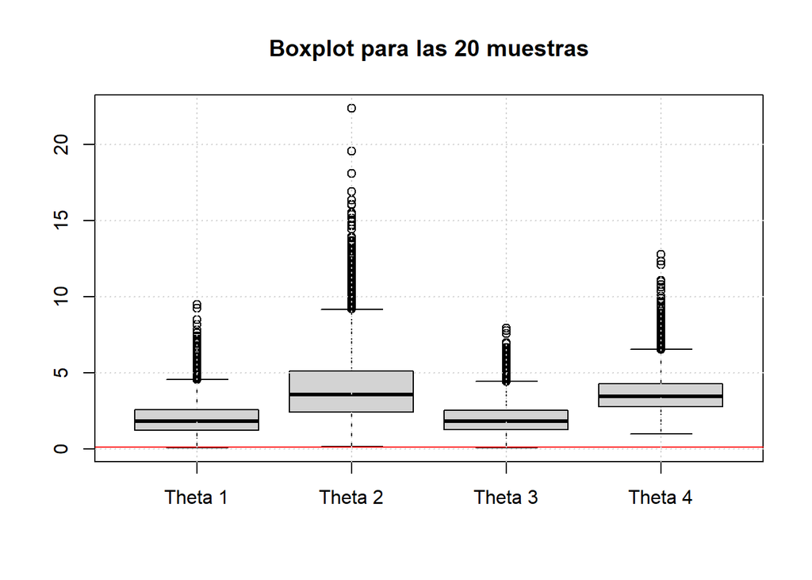

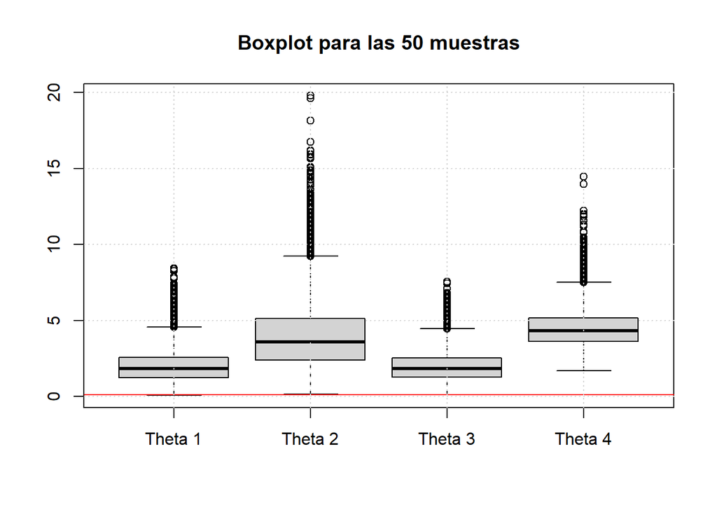

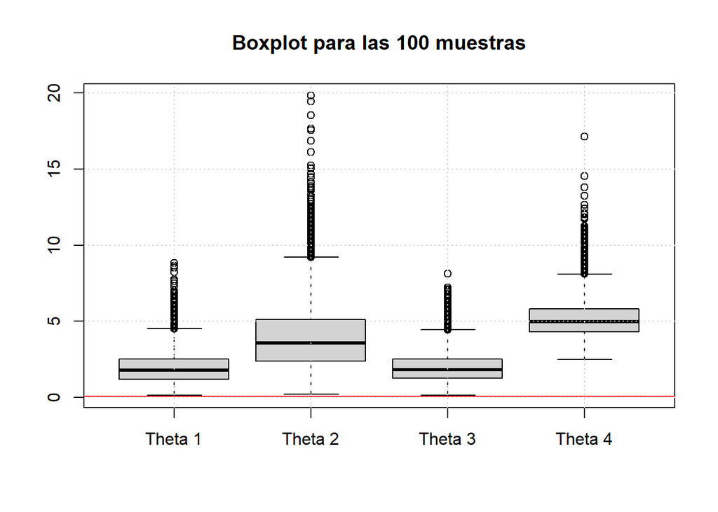

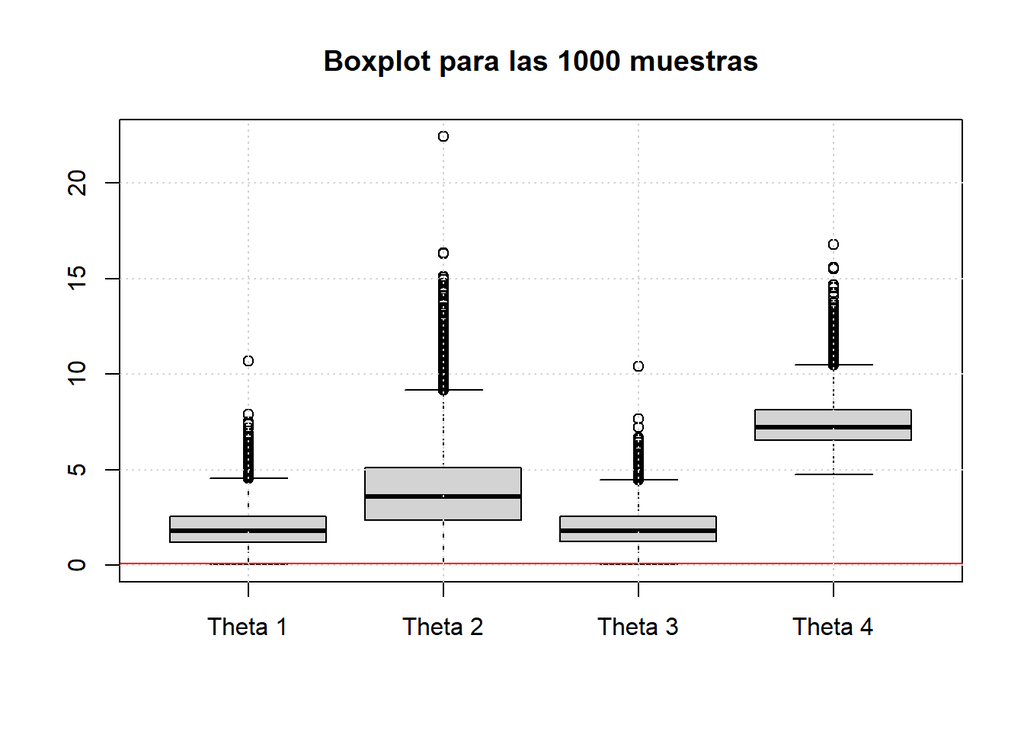